# Support Vector Classifier (SVC) Decision Boundary Visualization

## Overview

In this analysis, we use a Support Vector Classifier (SVC) to fit a linear model to synthetic data generated using `make_blobs`. This visualization illustrates the decision boundary and the support vectors.

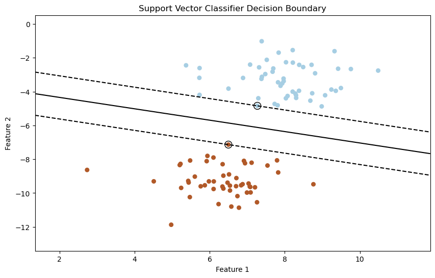

```python
import numpy as np
import matplotlib.pyplot as plt
from sklearn import svm
from sklearn.datasets import make_blobs

# Generate synthetic data
X, y = make_blobs(n_samples=100, centers=2, random_state=6)

# Fit the SVC model
clf = svm.SVC(kernel='linear')
clf.fit(X, y)

# Plotting the data and decision boundary
plt.figure(figsize=(10, 6))

# Plot the data points
plt.scatter(X[:, 0], X[:, 1], c=y, s=30, cmap=plt.cm.Paired)

# Create a mesh to plot the decision boundary
ax = plt.gca()
xlim = ax.get_xlim()
ylim = ax.get_ylim()

# Create grid to evaluate the model
xx = np.linspace(xlim[0]-1, xlim[1]+1, 500)
yy = np.linspace(ylim[0]-1, ylim[1]+1, 500)
YY, XX = np.meshgrid(yy, xx)
xy = np.vstack([XX.ravel(), YY.ravel()]).T

# Get the decision boundary and margins
Z = clf.decision_function(xy).reshape(XX.shape)

# Plot decision boundary and margins
contour = ax.contour(XX, YY, Z, levels=[-1, 0, 1], linestyles=['--', '-', '--'], colors='k')

# Highlight the support vectors
ax.scatter(clf.support_vectors_[:, 0], clf.support_vectors_[:, 1], s=100,
           linewidth=1, facecolors='none', edgecolors='k')

plt.title('Support Vector Classifier Decision Boundary')
plt.xlabel('Feature 1')
plt.ylabel('Feature 2')
plt.show()
```

# Iris Species Classification using Support Vector Classifier (SVC)

## Overview

In this analysis, we utilized a Support Vector Classifier (SVC) to classify iris flower species based on their petal length and petal width.

```
              sepal_length  sepal_width  petal_length  petal_width
sepal_length      1.000000    -0.117570      0.871754     0.817941
sepal_width      -0.117570     1.000000     -0.428440    -0.366126
petal_length      0.871754    -0.428440      1.000000     0.962865
petal_width       0.817941    -0.366126      0.962865     1.000000
```

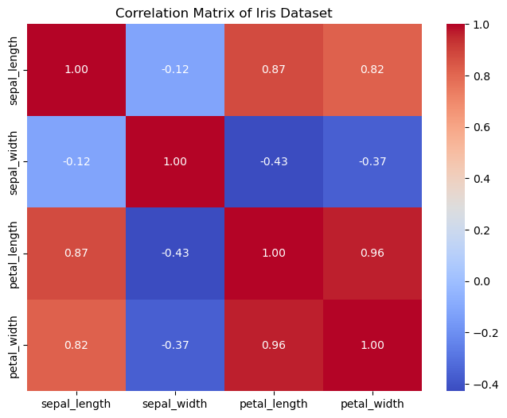

```
Confusion Matrix:
[[10  0  0]
 [ 0  9  0]
 [ 0  0 11]]

Classification Report:
              precision    recall  f1-score   support

           0       1.00      1.00      1.00        10
           1       1.00      1.00      1.00         9
           2       1.00      1.00      1.00        11

    accuracy                           1.00        30
   macro avg       1.00      1.00      1.00        30
weighted avg       1.00      1.00      1.00        30

Accuracy: 1.00
```

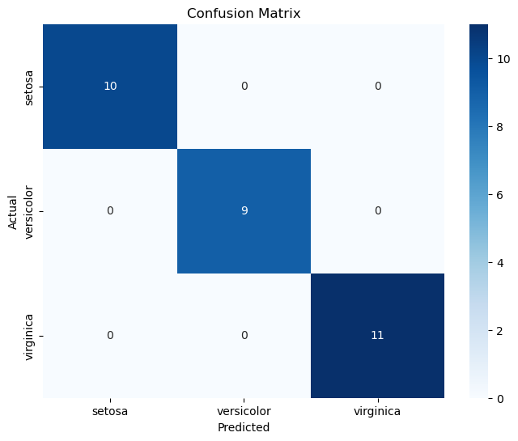

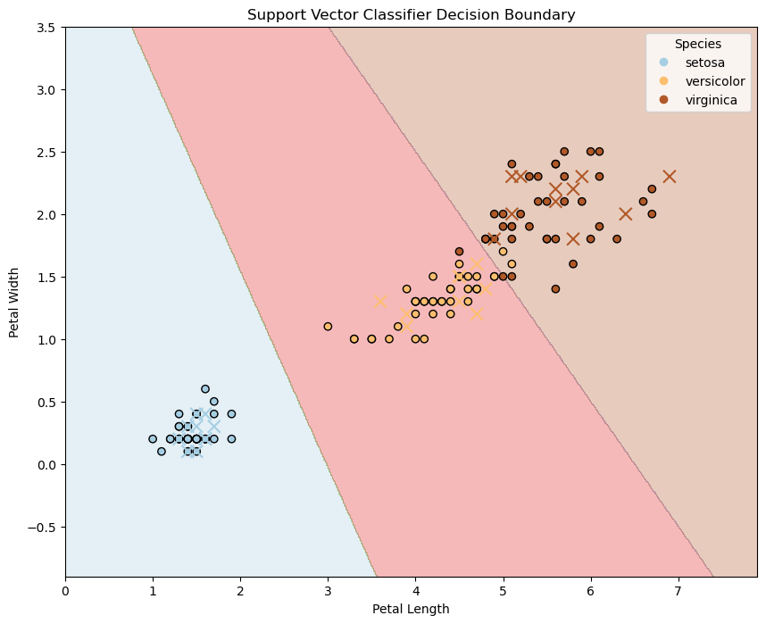

```python
# Import necessary libraries for data manipulation, visualization, and machine learning
import pandas as pd
import numpy as np
import matplotlib.pyplot as plt
import seaborn as sns
import re  # Import regular expressions module for string operations

# Import machine learning libraries
from sklearn.svm import SVC  # Support Vector Classifier
from sklearn.model_selection import train_test_split  # For splitting data into training and testing sets
from sklearn.metrics import classification_report, confusion_matrix, accuracy_score  # For evaluating model performance
from sklearn.preprocessing import LabelEncoder  # For converting categorical labels into numerical format

# Load the Iris dataset from seaborn library
df = sns.load_dataset('iris')

# Calculate the correlation matrix to understand relationships between numeric features
# This helps us to see how strongly features are related to each other
correlation_matrix = df.select_dtypes(include=['float64', 'int64']).corr()

# Print the correlation matrix to the console
print(correlation_matrix)

# Visualize the correlation matrix using a heatmap for better understanding
plt.figure(figsize=(8, 6))
sns.heatmap(correlation_matrix, annot=True, cmap='coolwarm', fmt=".2f")
plt.title('Correlation Matrix of Iris Dataset')
plt.show()

# Select two features for 2D visualization based on correlation
# We choose 'petal_length' and 'petal_width' because they have a strong positive correlation with each other
# These features are important for distinguishing between different species of iris flowers
X = df[['petal_length', 'petal_width']]
y = df['species']  # This is our target variable (what we want to predict)

# Encode the target variable (species names) into numerical format
label_encoder = LabelEncoder()
y_encoded = label_encoder.fit_transform(y)

# Split the data into training and testing sets (80% training, 20% testing)
X_train, X_test, y_train, y_test = train_test_split(X, y_encoded, test_size=0.20, random_state=42)

# Instantiate the SVC model with a linear kernel for classification
model = SVC(kernel='linear', decision_function_shape='ovr')

# Train the model using the training data
model.fit(X_train, y_train)

# Use the trained model to predict the species for the test set
y_pred = model.predict(X_test)

# Evaluate the model's performance using a confusion matrix and classification report
print("Confusion Matrix:")
print(confusion_matrix(y_test, y_pred))
print("\nClassification Report:")
print(classification_report(y_test, y_pred))

# Calculate and print the accuracy of the model
accuracy = accuracy_score(y_test, y_pred)
print(f"Accuracy: {accuracy:.2f}")

# Visualize the confusion matrix using a heatmap for better interpretation
plt.figure(figsize=(8, 6))
sns.heatmap(confusion_matrix(y_test, y_pred), annot=True, fmt='d', cmap='Blues',
            xticklabels=label_encoder.classes_, yticklabels=label_encoder.classes_)
plt.xlabel('Predicted')
plt.ylabel('Actual')
plt.title('Confusion Matrix')
plt.show()

# Plot the decision boundaries to visualize how the model separates different species
# Define the range for the plot based on the feature values
x_min, x_max = X['petal_length'].min() - 1, X['petal_length'].max() + 1
y_min, y_max = X['petal_width'].min() - 1, X['petal_width'].max() + 1

# Create a mesh grid for plotting decision boundaries
xx, yy = np.meshgrid(np.linspace(x_min, x_max, 500),
                     np.linspace(y_min, y_max, 500))

# Create a DataFrame for the grid to include feature names
grid = pd.DataFrame(np.c_[xx.ravel(), yy.ravel()], columns=['petal_length', 'petal_width'])

# Predict labels for each point in the mesh grid using the trained model
Z = model.predict(grid)
Z = Z.reshape(xx.shape)

# Plotting the decision boundaries
plt.figure(figsize=(10, 8))
plt.contourf(xx, yy, Z, alpha=0.3, cmap=plt.cm.Paired)

# Plot the training points
scatter = plt.scatter(X_train['petal_length'], X_train['petal_width'], c=y_train,
                      edgecolors='k', cmap=plt.cm.Paired)

# Plot the test points with different markers
plt.scatter(X_test['petal_length'], X_test['petal_width'], c=y_test,
            cmap=plt.cm.Paired, marker='x', s=100)

# Create a legend for the species
handles, labels = scatter.legend_elements()
# Extract the integer from the label strings
labels = [int(re.search(r'\{(\d+)\}', label).group(1)) for label in labels]
# Map the integer labels back to the original class names
class_labels = label_encoder.inverse_transform(labels)
plt.legend(handles, class_labels, title="Species")

# Set labels and title for the plot
plt.xlabel('Petal Length')
plt.ylabel('Petal Width')
plt.title('Support Vector Classifier Decision Boundary')
plt.show()
```

# Salary Prediction using Support Vector Regression (SVR)

## Overview

In this analysis, we used a Support Vector Regression (SVR) model to predict salaries based on years of experience. The dataset contains two columns: "YearsExperience" and "Salary".

```
   YearsExperience   Salary
0              1.1  39343.0
1              1.3  46205.0
2              1.5  37731.0
3              2.0  43525.0
4              2.2  39891.0
<class 'pandas.core.frame.DataFrame'>
RangeIndex: 30 entries, 0 to 29
Data columns (total 2 columns):
 #   Column           Non-Null Count  Dtype
---  ------           --------------  -----
 0   YearsExperience  30 non-null     float64
 1   Salary           30 non-null     float64
dtypes: float64(2)
memory usage: 608.0 bytes
None
Mean Squared Error: 49790269.56
R-squared: 0.90
```

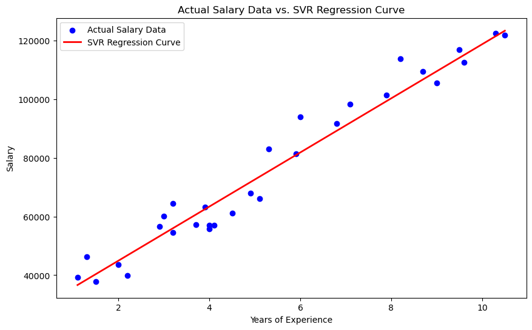

```python
# Import libraries
import pandas as pd  # Data manipulation library
import numpy as np   # Numerical computing library
import matplotlib.pyplot as plt  # Plotting library
import seaborn as sns  # Statistical data visualization library

# ML libraries
from sklearn.model_selection import train_test_split  # For splitting data
from sklearn.svm import SVR  # Support Vector Regression model
from sklearn.metrics import mean_squared_error, r2_score  # Evaluation metrics
from sklearn.preprocessing import StandardScaler  # For feature scaling

# Load the data
df = pd.read_csv('salary_data.csv')  # Read the dataset from a CSV file
print(df.head())  # Display the first few rows of the dataset

# Check the data summary
print(df.info())  # Show a summary of the dataset, including data types and non-null counts

# Features and target variable
X = df[['YearsExperience']].values  # Features (independent variable)
y = df['Salary'].values  # Target (dependent variable)

# Feature scaling (important for SVR)
# StandardScaler standardizes features by removing the mean and scaling to unit variance
scaler_X = StandardScaler()
scaler_y = StandardScaler()

X_scaled = scaler_X.fit_transform(X)  # Fit and transform the feature data
y_scaled = scaler_y.fit_transform(y.reshape(-1, 1)).ravel()  # Fit and transform the target data

# Train-test split the data
# Split the scaled data into training and testing sets (80% train, 20% test)
X_train, X_test, y_train, y_test = train_test_split(X_scaled, y_scaled, test_size=0.20, random_state=42)

# Instantiate the SVR model
# 'rbf' is the radial basis function kernel; it can capture non-linear relationships
model = SVR(kernel='linear')  # You can also try 'linear', 'poly', etc.

# Train the model
model.fit(X_train, y_train)  # Fit the SVR model to the training data

# Predict the model
y_pred_scaled = model.predict(X_test)  # Make predictions on the test set

# Inverse transform the predictions and test target
# The predictions made by the model are on a scaled (normalized) scale.
# We need to convert them back to the original scale for meaningful interpretation.

# Convert the scaled predictions back to original scale
# Reshape the predicted values to match the expected input shape of the inverse_transform method
y_pred = scaler_y.inverse_transform(y_pred_scaled.reshape(-1, 1)).ravel()
# This line takes the scaled predictions (y_pred_scaled), reshapes it to a 2D array (as required by the scaler),
# then applies the inverse transformation to get back to the original salary values.
# Finally, it flattens the array back to 1D for easier use.

# Similarly, we need to convert the actual test target values back to the original scale
y_test_original = scaler_y.inverse_transform(y_test.reshape(-1, 1)).ravel()
# Here, the actual test target values (y_test) are also reshaped and inverse transformed
# to convert them back to their original scale.
# This allows us to compare the predicted values directly with the original test values.


# Evaluate the model
mse = mean_squared_error(y_test_original, y_pred)  # Calculate Mean Squared Error
r2 = r2_score(y_test_original, y_pred)  # Calculate R-squared value

print(f"Mean Squared Error: {mse:.2f}")  # Print the MSE
print(f"R-squared: {r2:.2f}")  # Print the R-squared value

# Set the figure size for the plot
plt.figure(figsize=(10, 6))  # This defines the width and height of the plot.

# Scatter plot of actual salary data
plt.scatter(X, y, color='blue', label='Actual Salary Data')
# This plots the actual data points (Years of Experience vs. Salary) in blue for easy visibility.

# Sort the scaled feature values
X_plot = np.sort(X_scaled, axis=0)  # Sorting helps in smooth plotting.
# Sorting ensures that we plot the data in order, which is important for visualizing trends.
y_plot = model.predict(X_plot)  # Get predictions for the sorted features.
# We use the sorted values to make predictions, so the curve appears continuous.

# Convert scaled features back to original values
X_plot_original = scaler_X.inverse_transform(X_plot)  # Convert back to original scale for understanding.
# This changes the scaled values back to the original "Years of Experience" for a better interpretation.
y_plot_original = scaler_y.inverse_transform(y_plot.reshape(-1, 1)).ravel()  # Get original salary values.
# Similarly, this converts predicted salaries back to the original scale for clarity.

# Plot the regression curve with original values
plt.plot(X_plot_original, y_plot_original, color='red', linewidth=2, label='SVR Regression Curve')
# This plots the regression line (predicted salary) on top of the actual data points to show the model's performance.

# Title and labels
plt.title('Actual Salary Data vs. SVR Regression Curve')  # Title of the plot for context.
plt.xlabel('Years of Experience')  # Label for the X-axis to indicate what it represents.
plt.ylabel('Salary')  # Label for the Y-axis to indicate what it represents.
plt.legend()  # Shows the legend to differentiate between actual data and the regression curve.
plt.show()  # Displays the complete plot.
```

# Heart Disease Prediction using Support Vector Classifier

This notebook demonstrates how to predict heart disease using a Support Vector Classifier (SVC). The dataset contains various features related to patients' health.

```
Confusion Matrix:
[[24  5]
 [ 4 28]]

Classification Report:
              precision    recall  f1-score   support

           0       0.86      0.83      0.84        29
           1       0.85      0.88      0.86        32

    accuracy                           0.85        61
   macro avg       0.85      0.85      0.85        61
weighted avg       0.85      0.85      0.85        61

Accuracy: 0.85
```

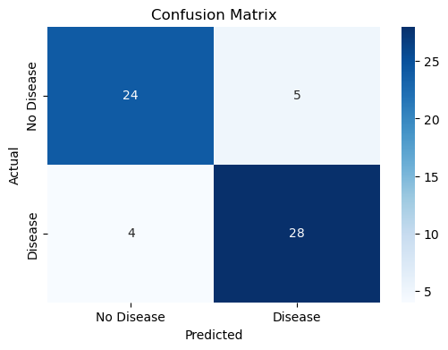

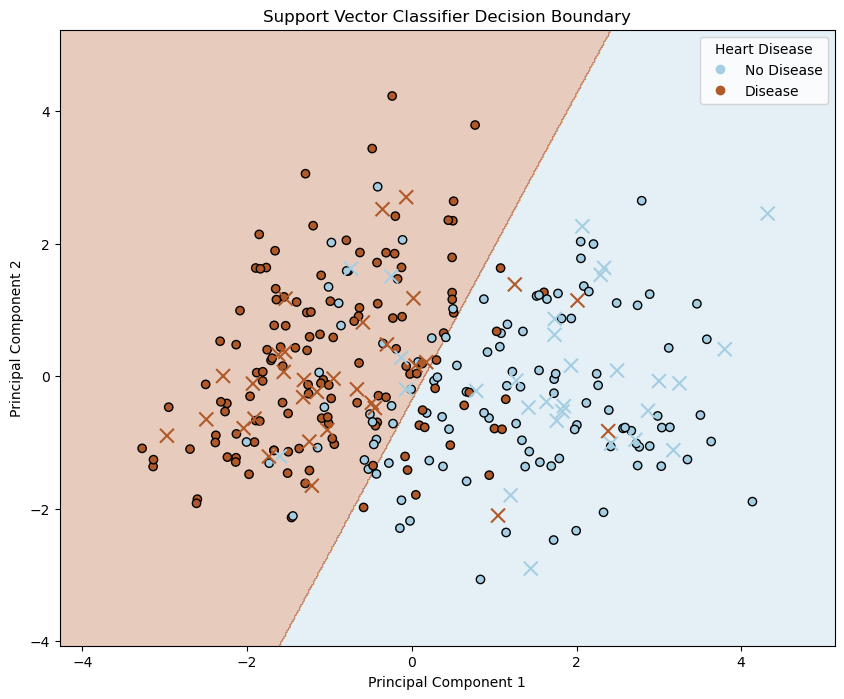

```python
# Import necessary libraries
import pandas as pd  # For handling data in a DataFrame format
import numpy as np  # For numerical operations
import matplotlib.pyplot as plt  # For creating plots and visualizations
import seaborn as sns  # For statistical data visualization
import re  # For regular expression operations

from sklearn.svm import SVC  # Support Vector Classifier for classification tasks
from sklearn.model_selection import train_test_split  # For splitting data into training and testing sets
from sklearn.preprocessing import StandardScaler  # For scaling features to improve model performance
from sklearn.decomposition import PCA  # For reducing dimensionality of data
from sklearn.metrics import classification_report, confusion_matrix, accuracy_score  # For evaluating model performance

# Load the dataset
df = pd.read_csv('heart.csv')  # Read the heart disease dataset from a CSV file

# Separate features and target variable
X = df.drop('target', axis=1)  # Get all columns except 'target' as features
y = df['target']  # 'target' column is our label indicating presence of heart disease

# Feature scaling
scaler = StandardScaler()  # Initialize the scaler
X_scaled = scaler.fit_transform(X)  # Scale the features so they have a mean of 0 and variance of 1

# Split the dataset into training and testing sets (80% train, 20% test)
X_train, X_test, y_train, y_test = train_test_split(X_scaled, y, test_size=0.20, random_state=42)

# Dimensionality reduction using PCA
# PCA (Principal Component Analysis) helps to reduce the number of features while retaining important information.
# Here, we are reducing the features to 2 dimensions for easier visualization.
pca = PCA(n_components=2)  # We want to reduce to 2 principal components
X_train_pca = pca.fit_transform(X_train)  # Fit PCA on training data and transform it
X_test_pca = pca.transform(X_test)  # Transform the test data using the same PCA model

# Train the Support Vector Classifier model
model = SVC(kernel='linear')  # Initialize SVC with a linear kernel
model.fit(X_train_pca, y_train)  # Train the model with the training data

# Make predictions using the trained model
y_pred = model.predict(X_test_pca)  # Predict the target for the test set

# Evaluate the model's performance
print("Confusion Matrix:")
print(confusion_matrix(y_test, y_pred))  # Display the confusion matrix
print("\nClassification Report:")
print(classification_report(y_test, y_pred))  # Display detailed classification metrics
accuracy = accuracy_score(y_test, y_pred)  # Calculate accuracy of the model
print(f"Accuracy: {accuracy:.2f}")  # Print the accuracy

# Visualize the confusion matrix using a heatmap
plt.figure(figsize=(6, 4))  # Set the figure size for the heatmap
sns.heatmap(confusion_matrix(y_test, y_pred), annot=True, fmt='d', cmap='Blues',
            xticklabels=['No Disease', 'Disease'], yticklabels=['No Disease', 'Disease'])
plt.xlabel('Predicted')  # X-axis label
plt.ylabel('Actual')  # Y-axis label
plt.title('Confusion Matrix')  # Title of the plot
plt.show()  # Display the plot

# Plot the decision boundary of the model
# We will create a mesh grid for the two principal components
x_min, x_max = X_train_pca[:, 0].min() - 1, X_train_pca[:, 0].max() + 1  # Define limits for x-axis
y_min, y_max = X_train_pca[:, 1].min() - 1, X_train_pca[:, 1].max() + 1  # Define limits for y-axis

# Create a grid of points to predict on
xx, yy = np.meshgrid(np.linspace(x_min, x_max, 500),
                     np.linspace(y_min, y_max, 500))

# Use the model to predict the class for each point in the grid
Z = model.predict(np.c_[xx.ravel(), yy.ravel()])  # Predict using the grid points
Z = Z.reshape(xx.shape)  # Reshape the predictions to match the grid shape

# Plotting the decision boundary
plt.figure(figsize=(10, 8))  # Set figure size
plt.contourf(xx, yy, Z, alpha=0.3, cmap=plt.cm.Paired)  # Plot the decision boundary with contour fill

# Scatter plot for training data points
scatter = plt.scatter(X_train_pca[:, 0], X_train_pca[:, 1], c=y_train,
                      edgecolors='k', cmap=plt.cm.Paired)

# Scatter plot for test data points with different markers
plt.scatter(X_test_pca[:, 0], X_test_pca[:, 1], c=y_test,
            cmap=plt.cm.Paired, marker='x', s=100)  # Use 'x' for test points

# Create a legend for the plot
handles, labels = scatter.legend_elements()  # Get legend elements from scatter plot
# Extract integer labels from legend
labels = [int(re.search(r'\{(\d+)\}', label).group(1)) for label in labels]
class_labels = ['No Disease', 'Disease']  # Map class labels
plt.legend(handles, class_labels, title="Heart Disease")  # Show legend with class names

plt.xlabel('Principal Component 1')  # X-axis label for the first principal component
plt.ylabel('Principal Component 2')  # Y-axis label for the second principal component
plt.title('Support Vector Classifier Decision Boundary')  # Title of the plot
plt.show()  # Display the plot
```

```
Confusion Matrix:
[[27  2]
 [ 5 27]]

Classification Report:
              precision    recall  f1-score   support

           0       0.84      0.93      0.89        29
           1       0.93      0.84      0.89        32

    accuracy                           0.89        61
   macro avg       0.89      0.89      0.89        61
weighted avg       0.89      0.89      0.89        61

Accuracy: 0.89
```

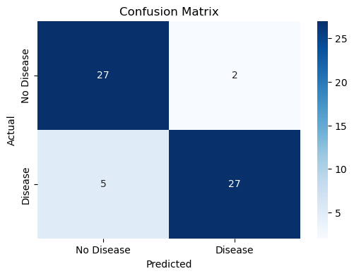

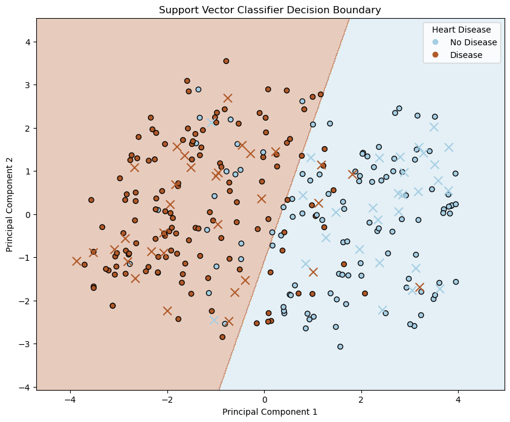

```python
# Import necessary libraries
import pandas as pd  # For data manipulation
import numpy as np  # For numerical operations
import matplotlib.pyplot as plt  # For plotting and visualizing data
import seaborn as sns  # For statistical data visualization
import re  # Regular expressions module for string operations

from sklearn.svm import SVC  # Support Vector Classifier for classification tasks
from sklearn.model_selection import train_test_split  # For splitting the dataset
from sklearn.preprocessing import StandardScaler, LabelEncoder  # For scaling and encoding features
from sklearn.decomposition import PCA  # For dimensionality reduction
from sklearn.metrics import classification_report, confusion_matrix, accuracy_score  # For model evaluation

# Load the dataset
df = pd.read_csv('heart.csv')  # Read heart disease data from a CSV file

# Separate features (X) and target variable (y)
X = df.drop('target', axis=1)  # All columns except 'target' are features
y = df['target']  # 'target' column indicates presence of heart disease

# Identify categorical variables
# Binary categorical variables (having only two values)
binary_features = ['sex', 'fbs', 'exang']

# Multiclass categorical variables (having more than two categories)
multiclass_features = ['cp', 'restecg', 'slope', 'ca', 'thal']

# Apply Label Encoding to binary categorical variables
label_encoder = LabelEncoder()  # Initialize the label encoder
for col in binary_features:
    X[col] = label_encoder.fit_transform(X[col])  # Convert categorical values to numerical (0 or 1)

# Apply One-Hot Encoding to multiclass categorical variables
X = pd.get_dummies(X, columns=multiclass_features)  # Create binary columns for each category

# Feature scaling
scaler = StandardScaler()  # Initialize the scaler
X_scaled = scaler.fit_transform(X)  # Scale the features to have a mean of 0 and standard deviation of 1

# Split the dataset into training and testing sets (80% train, 20% test)
X_train, X_test, y_train, y_test = train_test_split(X_scaled, y, test_size=0.20, random_state=42)

# Dimensionality reduction using PCA
# PCA (Principal Component Analysis) reduces the number of features while preserving essential information.
# Here, we reduce to 2 dimensions for easier visualization.
pca = PCA(n_components=2)  # Set number of principal components to 2
X_train_pca = pca.fit_transform(X_train)  # Fit PCA on training data and transform it
X_test_pca = pca.transform(X_test)  # Transform the test data using the same PCA model

# Train the Support Vector Classifier (SVC) model
model = SVC(kernel='linear')  # Initialize SVC with a linear kernel
model.fit(X_train_pca, y_train)  # Train the model with the training data

# Make predictions using the trained model
y_pred = model.predict(X_test_pca)  # Predict the target for the test set

# Evaluate the model's performance
print("Confusion Matrix:")
print(confusion_matrix(y_test, y_pred))  # Display the confusion matrix

print("\nClassification Report:")
print(classification_report(y_test, y_pred))  # Display detailed metrics of model performance

accuracy = accuracy_score(y_test, y_pred)  # Calculate accuracy
print(f"Accuracy: {accuracy:.2f}")  # Print the accuracy

# Visualize the confusion matrix using a heatmap
plt.figure(figsize=(6, 4))  # Set the figure size for the heatmap
sns.heatmap(confusion_matrix(y_test, y_pred), annot=True, fmt='d', cmap='Blues',
            xticklabels=['No Disease', 'Disease'], yticklabels=['No Disease', 'Disease'])
plt.xlabel('Predicted')  # Label for the x-axis
plt.ylabel('Actual')  # Label for the y-axis
plt.title('Confusion Matrix')  # Title of the plot
plt.show()  # Display the plot

# Plot the decision boundary of the model
# Create a mesh grid for the two principal components
x_min, x_max = X_train_pca[:, 0].min() - 1, X_train_pca[:, 0].max() + 1  # X-axis limits
y_min, y_max = X_train_pca[:, 1].min() - 1, X_train_pca[:, 1].max() + 1  # Y-axis limits

# Generate a grid of points to predict on
xx, yy = np.meshgrid(np.linspace(x_min, x_max, 500),
                     np.linspace(y_min, y_max, 500))

# Use the model to predict the class for each point in the grid
Z = model.predict(np.c_[xx.ravel(), yy.ravel()])  # Predict for all points in the grid
Z = Z.reshape(xx.shape)  # Reshape predictions to match the grid shape

# Plotting the decision boundary
plt.figure(figsize=(10, 8))  # Set figure size
plt.contourf(xx, yy, Z, alpha=0.3, cmap=plt.cm.Paired)  # Plot the decision boundary

# Scatter plot for training data points
scatter = plt.scatter(X_train_pca[:, 0], X_train_pca[:, 1], c=y_train,
                      edgecolors='k', cmap=plt.cm.Paired)

# Scatter plot for test data points with a different marker
plt.scatter(X_test_pca[:, 0], X_test_pca[:, 1], c=y_test,
            cmap=plt.cm.Paired, marker='x', s=100)  # Use 'x' for test points

# Create a legend for the plot
handles, labels = scatter.legend_elements()  # Get legend elements from scatter plot
# Extract integer labels from legend
labels = [int(re.search(r'\{(\d+)\}', label).group(1)) for label in labels]
class_labels = ['No Disease', 'Disease']  # Map class labels
plt.legend(handles, class_labels, title="Heart Disease")  # Show legend with class names

plt.xlabel('Principal Component 1')  # Label for the first principal component
plt.ylabel('Principal Component 2')  # Label for the second principal component
plt.title('Support Vector Classifier Decision Boundary')  # Title of the plot
plt.show()  # Display the plot
```

**Understanding the Need for Encoding in the Heart Disease Dataset**

*That's an excellent question:*

*"This dataset is already in numeric representation, so why was encoding applied?"*

**Explanation:**

Even though the dataset features are stored as numeric data types (`int64` and `float64`), many of these features represent **categorical variables**, not continuous numerical variables. Machine learning algorithms like Support Vector Machines (SVM) require careful handling of categorical variables to avoid misinterpretation.

### 1. Difference Between Data Type and Data Nature

- **Data Type:** How data is stored in memory (e.g., integers, floats).
- **Data Nature:** What the data represents (e.g., categories, measurements).

*Key Point:* Just because data is stored as numbers doesn't mean it's appropriate to treat it as continuous numerical data in modeling.

### 2. Categorical Variables Stored as Numbers

In the Heart Disease dataset, several features are categorical but represented numerically:

- **Binary Categorical Variables:**
  - `sex`: 0 = female, 1 = male.
  - `fbs` (fasting blood sugar): 0 = ≤120 mg/dl, 1 = >120 mg/dl.
  - `exang` (exercise-induced angina): 0 = no, 1 = yes.
- **Nominal Categorical Variables:**
  - `cp` (chest pain type): Values 0–3, each representing a different type.
  - `restecg` (resting ECG results): Values 0–2.
  - `slope` (slope of peak exercise ST segment): Values 0–2.
  - `ca` (number of major vessels): Values 0–4.
  - `thal` (thalassemia): Values 0–3.

*These numerical codes represent categories, not quantities.*

### 3. Why Encoding is Necessary

#### a. Preventing Misinterpretation by the Model

- **Ordinal Assumption Risk:**
  - SVM might interpret the numerical codes as having an order (e.g., `thal` value 3 is greater than 1), which may not reflect the actual relationship.
- **Distance Calculations:**
  - SVM relies on calculating distances between feature values.
  - Treating categorical codes as continuous numbers can distort these distances, leading to incorrect model predictions.

#### b. Ensuring Accurate Representation of Categories

- **One-Hot Encoding for Nominal Variables:**
  - Converts categories into binary vectors.

  **Benefits:**
  - Prevents the model from assuming any ordinal relationship.
  - Each category is represented independently.
- **Label Encoding for Binary Variables:**
  - Suitable when only two categories exist.

  **Benefits:**
  - Simpler representation.
  - No risk of misinterpreting the ordinal relationship since only two states exist.

### 4. Consequences of Not Encoding

- **Incorrect Model Learning:**
  - The model may learn patterns based on the numerical ordering of categories, which don't exist.
- **Reduced Model Performance:**
  - Predictions may be less accurate.
  - The model may not generalize well to new data.
- **Misinterpretation of Results:**
  - It becomes challenging to interpret feature importance and model behavior.

### 5. Example: Chest Pain Type (`cp`)

- **Categories:**
  - 0: Typical angina.
  - 1: Atypical angina.
  - 2: Non-anginal pain.
  - 3: Asymptomatic.
- **Issue Without Encoding:**
  - The model might incorrectly assume that `cp=3` is three times more significant than `cp=1`.
- **Solution: One-Hot Encoding**

  **Benefits:**
  - Each chest pain type is treated as a separate feature.
  - The model does not assume any ordinal relationship.

### 6. When Encoding is Not Applied

- **Model Misinterpretation:**
  - SVM may interpret the integer codes as continuous values, leading to erroneous distance calculations.
- **Example with `thal`:**
  - Categories might represent:
    - 0: Normal.
    - 1: Fixed defect.
    - 2: Reversible defect.
  - Without encoding, the model might treat `thal=2` as twice `thal=1`, which is incorrect.

### 7. Conclusion

- **Encoding is Essential:**
  - To accurately capture the nature of categorical variables.
  - To prevent the model from making incorrect assumptions.
- **Ensures Model Effectiveness:**
  - Proper encoding leads to better model performance and more reliable predictions.
- **Aligns with Machine Learning Best Practices:**
  - Encoding categorical variables is a standard step in data preprocessing.

### **Final Thoughts**

While the dataset is numerically represented, the meaning behind those numbers is crucial. Encoding ensures that we respect the categorical nature of certain features, enabling the SVM model to learn meaningful patterns and make accurate predictions.

# House Price Prediction Using Machine Learning

This notebook demonstrates how to predict house prices based on various features such as median income, house age, average rooms, etc., using machine learning techniques.

### RBF

```
<class 'pandas.core.frame.DataFrame'>
RangeIndex: 20640 entries, 0 to 20639
Data columns (total 9 columns):
 #   Column      Non-Null Count  Dtype
---  ------      --------------  -----
 0   MedInc      20640 non-null  float64
 1   HouseAge    20640 non-null  float64
 2   AveRooms    20640 non-null  float64
 3   AveBedrms   20640 non-null  float64
 4   Population  20640 non-null  float64
 5   AveOccup    20640 non-null  float64
 6   Latitude    20640 non-null  float64
 7   Longitude   20640 non-null  float64
 8   Price       20640 non-null  float64
dtypes: float64(9)
memory usage: 1.4 MB
None
Mean Squared Error: 0.35
R-squared: 0.73
```

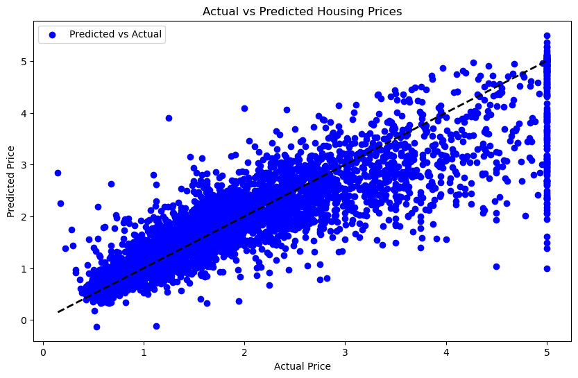

```python
# Import libraries
import pandas as pd  # Data manipulation library
import numpy as np   # Numerical computing library
import matplotlib.pyplot as plt  # Plotting library
import seaborn as sns  # Statistical data visualization library

# ML libraries
from sklearn.model_selection import train_test_split  # For splitting data
from sklearn.svm import SVR  # Support Vector Regression model
from sklearn.metrics import mean_squared_error, r2_score  # Evaluation metrics
from sklearn.preprocessing import StandardScaler  # For feature scaling

# Load the Heart Disease dataset
url = "house_data.csv"
df = pd.read_csv(url)

# Check the data summary
print(df.info())  # Show a summary of the dataset, including data types and non-null counts

# Features and target variable
X = df.drop('Price', axis=1).values  # Features (independent variables)
y = df['Price'].values  # Target (dependent variable)

# Feature scaling (important for SVR)
# StandardScaler standardizes features by removing the mean and scaling to unit variance
scaler_X = StandardScaler()
scaler_y = StandardScaler()

X_scaled = scaler_X.fit_transform(X)  # Fit and transform the feature data
y_scaled = scaler_y.fit_transform(y.reshape(-1, 1)).ravel()  # Fit and transform the target data

# Train-test split the data
# Split the scaled data into training and testing sets (80% train, 20% test)
X_train, X_test, y_train, y_test = train_test_split(
    X_scaled, y_scaled, test_size=0.20, random_state=42)

# Instantiate the SVR model
# 'rbf' is the radial basis function kernel; it can capture non-linear relationships
model = SVR(kernel='rbf')

# Train the model
model.fit(X_train, y_train)

# Predict the model
y_pred_scaled = model.predict(X_test)

# Inverse transform the predictions and test target
y_pred = scaler_y.inverse_transform(y_pred_scaled.reshape(-1, 1)).ravel()
y_test_original = scaler_y.inverse_transform(y_test.reshape(-1, 1)).ravel()

# Evaluate the model
mse = mean_squared_error(y_test_original, y_pred)
r2 = r2_score(y_test_original, y_pred)

print(f"Mean Squared Error: {mse:.2f}")
print(f"R-squared: {r2:.2f}")

# Optional: Visualize the results (since there are multiple features, we'll use a scatter plot)
plt.figure(figsize=(10, 6))
plt.scatter(y_test_original, y_pred, color='blue', label='Predicted vs Actual')
plt.plot([y_test_original.min(), y_test_original.max()],
         [y_test_original.min(), y_test_original.max()], 'k--', lw=2)
plt.xlabel('Actual Price')
plt.ylabel('Predicted Price')
plt.title('Actual vs Predicted Housing Prices')
plt.legend()
plt.show()
```

#### Linear

```
<class 'pandas.core.frame.DataFrame'>
RangeIndex: 20640 entries, 0 to 20639
Data columns (total 9 columns):
 #   Column      Non-Null Count  Dtype
---  ------      --------------  -----
 0   MedInc      20640 non-null  float64
 1   HouseAge    20640 non-null  float64
 2   AveRooms    20640 non-null  float64
 3   AveBedrms   20640 non-null  float64
 4   Population  20640 non-null  float64
 5   AveOccup    20640 non-null  float64
 6   Latitude    20640 non-null  float64
 7   Longitude   20640 non-null  float64
 8   Price       20640 non-null  float64
dtypes: float64(9)
memory usage: 1.4 MB
None
Mean Squared Error: 0.58
R-squared: 0.56
```

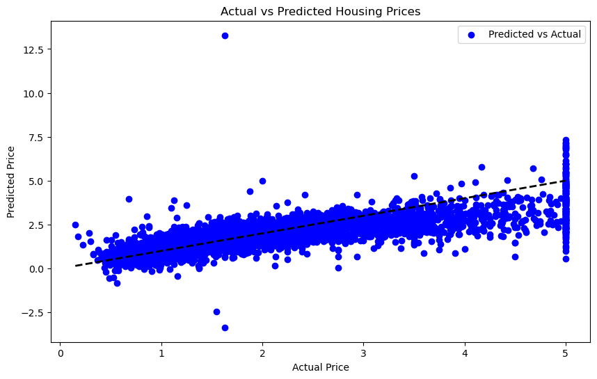

```python
# Import libraries
import pandas as pd  # Data manipulation library
import numpy as np   # Numerical computing library
import matplotlib.pyplot as plt  # Plotting library
import seaborn as sns  # Statistical data visualization library

# ML libraries
from sklearn.model_selection import train_test_split  # For splitting data
from sklearn.svm import SVR  # Support Vector Regression model
from sklearn.metrics import mean_squared_error, r2_score  # Evaluation metrics
from sklearn.preprocessing import StandardScaler  # For feature scaling

# Load the Heart Disease dataset
url = "house_data.csv"
df = pd.read_csv(url)

# Check the data summary
print(df.info())  # Show a summary of the dataset, including data types and non-null counts

# Features and target variable
X = df.drop('Price', axis=1).values  # Features (independent variables)
y = df['Price'].values  # Target (dependent variable)

# Feature scaling (important for SVR)
# StandardScaler standardizes features by removing the mean and scaling to unit variance
scaler_X = StandardScaler()
scaler_y = StandardScaler()

X_scaled = scaler_X.fit_transform(X)  # Fit and transform the feature data
y_scaled = scaler_y.fit_transform(y.reshape(-1, 1)).ravel()  # Fit and transform the target data

# Train-test split the data
# Split the scaled data into training and testing sets (80% train, 20% test)
X_train, X_test, y_train, y_test = train_test_split(
    X_scaled, y_scaled, test_size=0.20, random_state=42)

# Instantiate the SVR model
# 'rbf' is the radial basis function kernel; it can capture non-linear relationships
model = SVR(kernel='linear')

# Train the model
model.fit(X_train, y_train)

# Predict the model
y_pred_scaled = model.predict(X_test)

# Inverse transform the predictions and test target
y_pred = scaler_y.inverse_transform(y_pred_scaled.reshape(-1, 1)).ravel()
y_test_original = scaler_y.inverse_transform(y_test.reshape(-1, 1)).ravel()

# Evaluate the model
mse = mean_squared_error(y_test_original, y_pred)
r2 = r2_score(y_test_original, y_pred)

print(f"Mean Squared Error: {mse:.2f}")
print(f"R-squared: {r2:.2f}")

# Optional: Visualize the results (since there are multiple features, we'll use a scatter plot)
plt.figure(figsize=(10, 6))
plt.scatter(y_test_original, y_pred, color='blue', label='Predicted vs Actual')
plt.plot([y_test_original.min(), y_test_original.max()],
         [y_test_original.min(), y_test_original.max()], 'k--', lw=2)
plt.xlabel('Actual Price')
plt.ylabel('Predicted Price')
plt.title('Actual vs Predicted Housing Prices')
plt.legend()
plt.show()
```

#### Poly

```
<class 'pandas.core.frame.DataFrame'>
RangeIndex: 20640 entries, 0 to 20639
Data columns (total 9 columns):
 #   Column      Non-Null Count  Dtype
---  ------      --------------  -----
 0   MedInc      20640 non-null  float64
 1   HouseAge    20640 non-null  float64
 2   AveRooms    20640 non-null  float64
 3   AveBedrms   20640 non-null  float64
 4   Population  20640 non-null  float64
 5   AveOccup    20640 non-null  float64
 6   Latitude    20640 non-null  float64
 7   Longitude   20640 non-null  float64
 8   Price       20640 non-null  float64
dtypes: float64(9)
memory usage: 1.4 MB
None
Mean Squared Error: 1.08
R-squared: 0.18
```

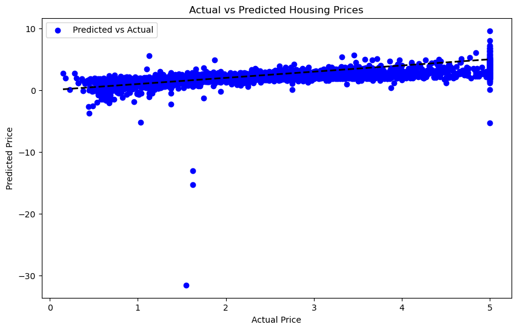

```python
# Import libraries
import pandas as pd  # Data manipulation library
import numpy as np   # Numerical computing library
import matplotlib.pyplot as plt  # Plotting library
import seaborn as sns  # Statistical data visualization library

# ML libraries
from sklearn.model_selection import train_test_split  # For splitting data
from sklearn.svm import SVR  # Support Vector Regression model
from sklearn.metrics import mean_squared_error, r2_score  # Evaluation metrics
from sklearn.preprocessing import StandardScaler  # For feature scaling

# Load the Heart Disease dataset
url = "house_data.csv"
df = pd.read_csv(url)

# Check the data summary
print(df.info())  # Show a summary of the dataset, including data types and non-null counts

# Features and target variable
X = df.drop('Price', axis=1).values  # Features (independent variables)
y = df['Price'].values  # Target (dependent variable)

# Feature scaling (important for SVR)
# StandardScaler standardizes features by removing the mean and scaling to unit variance
scaler_X = StandardScaler()
scaler_y = StandardScaler()

X_scaled = scaler_X.fit_transform(X)  # Fit and transform the feature data
y_scaled = scaler_y.fit_transform(y.reshape(-1, 1)).ravel()  # Fit and transform the target data

# Train-test split the data
# Split the scaled data into training and testing sets (80% train, 20% test)
X_train, X_test, y_train, y_test = train_test_split(
    X_scaled, y_scaled, test_size=0.20, random_state=42)

# Instantiate the SVR model
# 'rbf' is the radial basis function kernel; it can capture non-linear relationships
model = SVR(kernel='poly')

# Train the model
model.fit(X_train, y_train)

# Predict the model
y_pred_scaled = model.predict(X_test)

# Inverse transform the predictions and test target
y_pred = scaler_y.inverse_transform(y_pred_scaled.reshape(-1, 1)).ravel()
y_test_original = scaler_y.inverse_transform(y_test.reshape(-1, 1)).ravel()

# Evaluate the model
mse = mean_squared_error(y_test_original, y_pred)
r2 = r2_score(y_test_original, y_pred)

print(f"Mean Squared Error: {mse:.2f}")
print(f"R-squared: {r2:.2f}")

# Optional: Visualize the results (since there are multiple features, we'll use a scatter plot)
plt.figure(figsize=(10, 6))
plt.scatter(y_test_original, y_pred, color='blue', label='Predicted vs Actual')
plt.plot([y_test_original.min(), y_test_original.max()],
         [y_test_original.min(), y_test_original.max()], 'k--', lw=2)
plt.xlabel('Actual Price')
plt.ylabel('Predicted Price')
plt.title('Actual vs Predicted Housing Prices')
plt.legend()
plt.show()
```

# Non Linear Support Vector regression

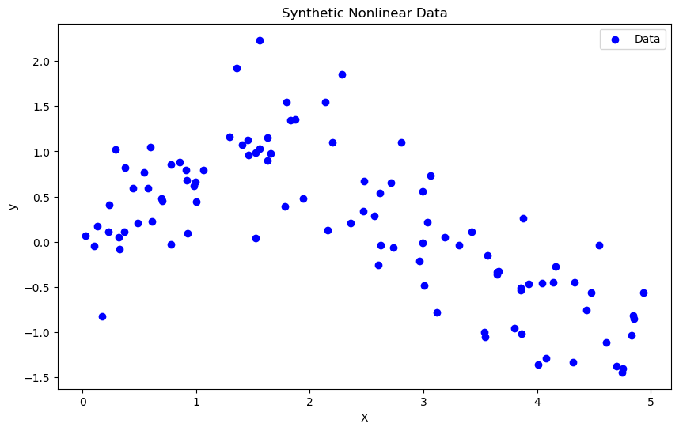

```
Mean Squared Error: 0.166
R-squared: 0.719
```

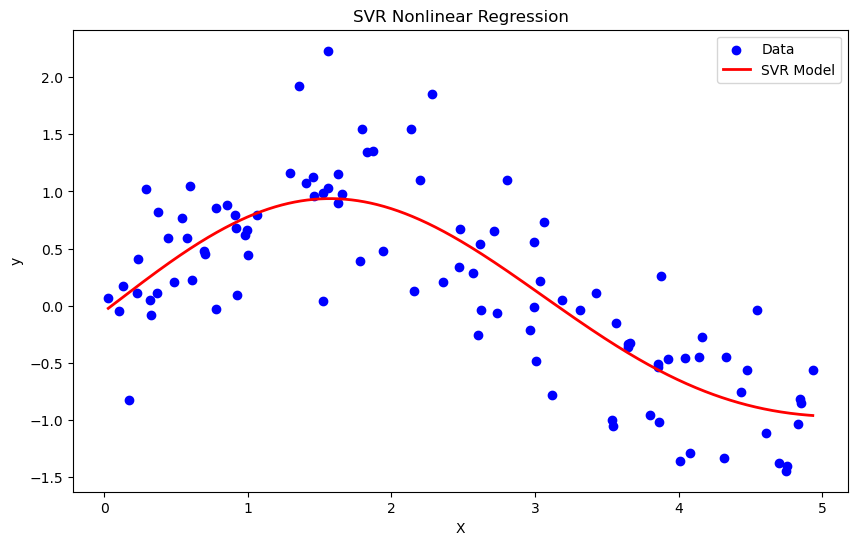

```python
# Import libraries
import numpy as np
import matplotlib.pyplot as plt
from sklearn.svm import SVR
from sklearn.model_selection import train_test_split
from sklearn.metrics import mean_squared_error, r2_score

# Generate synthetic nonlinear data
np.random.seed(42)
X = np.sort(5 * np.random.rand(100, 1), axis=0)
y = np.sin(X).ravel() + 0.5 * np.random.randn(100)

# Visualize the dataset
plt.figure(figsize=(10, 6))
plt.scatter(X, y, color='blue', label='Data')
plt.title('Synthetic Nonlinear Data')
plt.xlabel('X')
plt.ylabel('y')
plt.legend()
plt.show()

# Split the data
X_train, X_test, y_train, y_test = train_test_split(
    X, y, test_size=0.2, random_state=42)

# Instantiate the SVR model with RBF kernel
svr_rbf = SVR(kernel='rbf', C=100, gamma=0.1, epsilon=0.1)

# Train the model
svr_rbf.fit(X_train, y_train)

# Predict on the test set
y_pred = svr_rbf.predict(X_test)

# Evaluate the model
mse = mean_squared_error(y_test, y_pred)
r2 = r2_score(y_test, y_pred)

print(f"Mean Squared Error: {mse:.3f}")
print(f"R-squared: {r2:.3f}")

# Plot the regression results
X_plot = np.linspace(X.min(), X.max(), 1000).reshape(-1, 1)
y_plot = svr_rbf.predict(X_plot)

plt.figure(figsize=(10, 6))
plt.scatter(X, y, color='blue', label='Data')
plt.plot(X_plot, y_plot, color='red', linewidth=2, label='SVR Model')
plt.title('SVR Nonlinear Regression')
plt.xlabel('X')
plt.ylabel('y')
plt.legend()
plt.show()
```

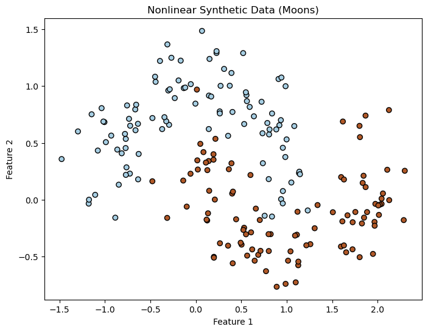

```
Classification Report:
              precision    recall  f1-score   support

           0       0.91      0.95      0.93        22
           1       0.94      0.89      0.91        18

    accuracy                           0.93        40
   macro avg       0.93      0.92      0.92        40
weighted avg       0.93      0.93      0.92        40

Confusion Matrix:
[[21  1]
 [ 2 16]]
Accuracy: 0.93
```

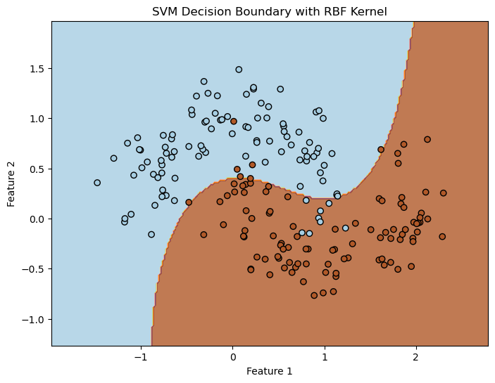

```python
# Import libraries
import numpy as np
import matplotlib.pyplot as plt
from sklearn import svm
from sklearn.datasets import make_moons
from sklearn.model_selection import train_test_split
from sklearn.metrics import classification_report, confusion_matrix, accuracy_score

# Generate synthetic nonlinear data (moons)
X, y = make_moons(n_samples=200, noise=0.2, random_state=42)

# Visualize the dataset
plt.figure(figsize=(8, 6))
plt.scatter(X[:, 0], X[:, 1], c=y, cmap=plt.cm.Paired, edgecolors='k')
plt.title("Nonlinear Synthetic Data (Moons)")
plt.xlabel('Feature 1')
plt.ylabel('Feature 2')
plt.show()

# Split the data
X_train, X_test, y_train, y_test = train_test_split(
    X, y, test_size=0.20, random_state=42)

# Create SVM classifier with RBF kernel
clf = svm.SVC(kernel='rbf', gamma='auto')

# Train the model
clf.fit(X_train, y_train)

# Make predictions on the test set
y_pred = clf.predict(X_test)

# Evaluate the model
print("Classification Report:")
print(classification_report(y_test, y_pred))

print("Confusion Matrix:")
print(confusion_matrix(y_test, y_pred))

print(f"Accuracy: {accuracy_score(y_test, y_pred):.2f}")

# Plot the decision boundaries
# Create a mesh to plot in
h = .02  # Step size in the mesh

# Determine the boundaries of the mesh grid
x_min, x_max = X[:, 0].min() - .5, X[:, 0].max() + .5
y_min, y_max = X[:, 1].min() - .5, X[:, 1].max() + .5

# Create mesh grid
xx, yy = np.meshgrid(np.arange(x_min, x_max, h),
                     np.arange(y_min, y_max, h))

# Predict over the mesh grid
Z = clf.predict(np.c_[xx.ravel(), yy.ravel()])

# Reshape the prediction results
Z = Z.reshape(xx.shape)

# Plot the contour and training examples
plt.figure(figsize=(8, 6))
plt.contourf(xx, yy, Z, cmap=plt.cm.Paired, alpha=0.8)

# Plot the original data points
plt.scatter(X[:, 0], X[:, 1], c=y, cmap=plt.cm.Paired, edgecolors='k')

plt.title("SVM Decision Boundary with RBF Kernel")
plt.xlabel('Feature 1')
plt.ylabel('Feature 2')
plt.show()
```